# Activity Prediction

Dan Hathway

April 6, 2017

```r
read.csv("https://d396qusza40orc.cloudfront.net/predmachlearn/pml-training.csv", na.strings=c("NA","#DIV/0!", "")) ->train
read.csv("https://d396qusza40orc.cloudfront.net/predmachlearn/pml-testing.csv", na.strings=c("NA","#DIV/0!", "")) ->test
```

## Build Model

The following steps were used to build the model. The datasets were imported. After initial examination, the first 7 non-predictive columns were removed from both training and testing data.

```r
## remove x and following 6 non-predictive columns but save for test set
train[,-c(1:7)] -> train
test[,c(1:7)] -> savetestcols
test[,-c(1:7)] -> test
## find out which columns have more than 95% of data missing
colSums(is.na(train)) ->badcols
nrow(train) * 0.95 -> cutoff
## remove them
train[,badcols < cutoff] ->train
test[,badcols < cutoff] ->test
```

Each remaining column in the initial training set was assessed according to whether at least 5% of its rows had data present. Columns failing that test were removed, leaving 53 variables.

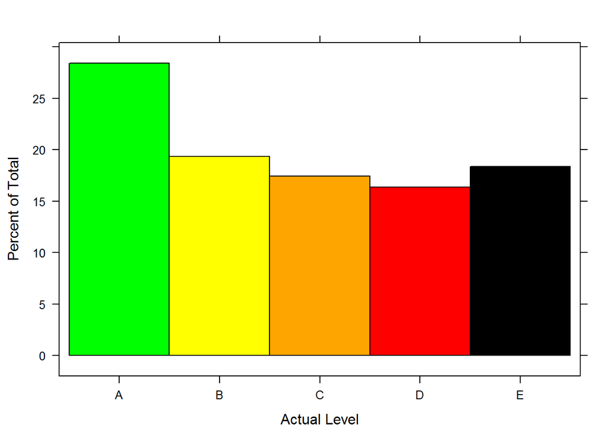

```r
## split training into sub-training / new testing on 60:40 ratio
new_split <- createDataPartition(y=train$classe, p=0.60, list=FALSE)
sub_train <- train[new_split, ]
sub_test <- train[-new_split, ]
histogram(sub_train$classe,col=c("green","yellow","orange","red","black"),xlab="Actual Level")
```

```r
x <- preProcess(sub_train)
x1 <- predict(x,sub_train)
## zero/near zero variance tests
nearZeroVar(x1,saveMetrics=TRUE) -> zvt
sum(zvt$zeroVar)
```

```
## [1] 0
```

```r
sum(zvt$nzv)
```

```
## [1] 0
```

```r
##
```

Preprocessing was perfomed to provide variance testing. It was shown that all 53 variables were valid model inputs.

```r
model1 <- rpart(classe ~ ., data=sub_train, method="class")
predict1 <- predict(model1, sub_test, type = "class")
cm <- confusionMatrix(predict1, sub_test$classe)
cm$overall[1]
```

```
##  Accuracy
## 0.7352791
```

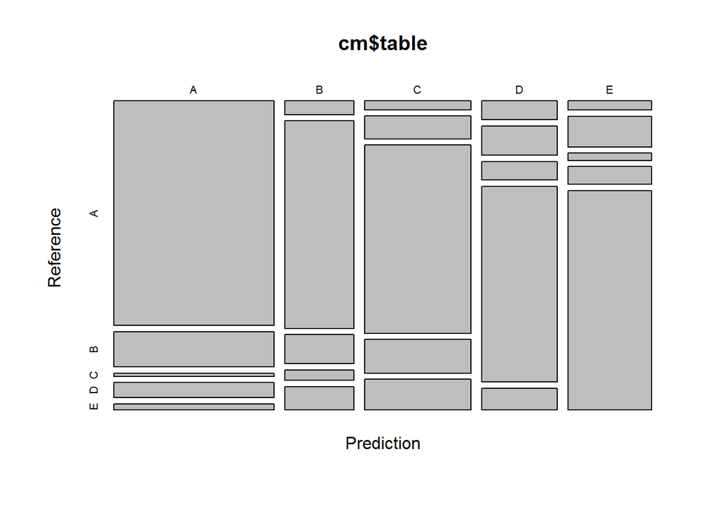

```r
plot(cm$table)
```

The rational for model selection is to try at least 2 different models, with the aim of at least 97.5% accuracy in a final model. The number of variables and fixed set of possible outcomes seem to suggest a tree method will work best.

```r
model2 <- randomForest(classe ~ ., data=sub_train, method="class")
predict2 <- predict(model2, sub_test)
cm2 <- confusionMatrix(predict2, sub_test$classe)
cm2$overall[1]
```

```
##  Accuracy
## 0.9940097
```

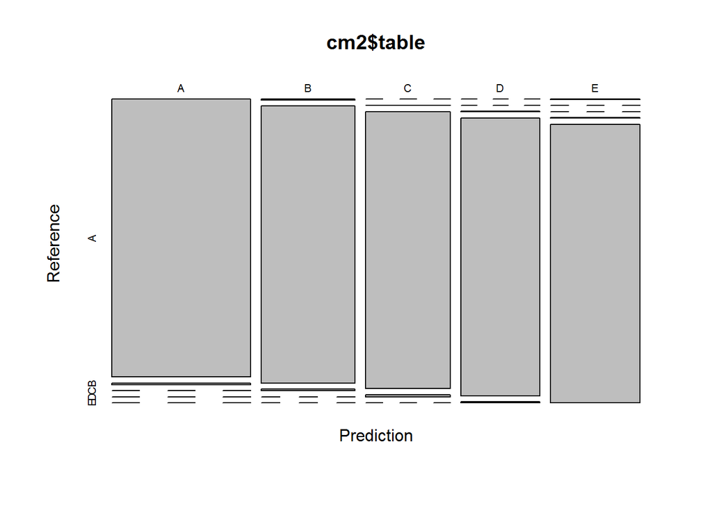

```r
plot(cm2$table)
```

The second model used randomForest. This created results with over 99% accuracy. No further modeling or any combination was thought to be required, but cross-validation using the cv method will be performed. An error rate of no greater than 2% is expected.

```r
## cross validate second model
cp <-trainControl(method="cv",number=3)
train (classe~.,data=sub_train,method="rf",trControl=cp) ->model2a
## look at the model
model2a$finalModel
```

```
##
## Call:
##  randomForest(x = x, y = y, mtry = param$mtry)
##                Type of random forest: classification
##                      Number of trees: 500
## No. of variables tried at each split: 27
##
##         OOB estimate of  error rate: 0.78%
## Confusion matrix:
##      A    B    C    D    E class.error
## A 3342    4    2    0    0 0.001792115
## B   21 2248    9    0    1 0.013602457
## C    0   14 2037    3    0 0.008276534
## D    0    1   23 1904    2 0.013471503
## E    0    2    3    7 2153 0.005542725
```

```r
## apply model 2 to test data
predict2a <-predict(model2a,test)
cbind(classe=predict2a,savetestcols,test) -> testresults
testresults
```

```
##    classe  X user_name raw_timestamp_part_1 raw_timestamp_part_2
## 1       B  1     pedro           1323095002               868349
## 2       A  2    jeremy           1322673067               778725
## 3       B  3    jeremy           1322673075               342967
## 4       A  4    adelmo           1322832789               560311
## 5       A  5    eurico           1322489635               814776
## 6       E  6    jeremy           1322673149               510661
## 7       D  7    jeremy           1322673128               766645
## 8       B  8    jeremy           1322673076                54671
## 9       A  9  carlitos           1323084240               916313
## 10      A 10   charles           1322837822               384285
## 11      B 11  carlitos           1323084277                36553
## 12      C 12    jeremy           1322673101               442731
## 13      B 13    eurico           1322489661               298656
## 14      A 14    jeremy           1322673043               178652
```

[output cut: 258 more lines]